# Библиотеки и настройка cuda

```python
import warnings
warnings.filterwarnings('ignore')
import pandas as pd
```

```python
from ultralytics import YOLO
```

```python
import cv2
```

```python
import torch

print(torch.cuda.is_available())
print(torch.cuda.get_device_name())
```

```
True
NVIDIA GeForce RTX 2080 SUPER
```

# Модуль Б. Разработка модели машинного обучения

Поставленную задачу можно разбить на две: детекцию лиц и идентификацию детектируемого лица, -> для решения нужно использовать две модели:

> -- модель детекции

> -- модель распознавания лиц

Для детекции были выбраны модели YOLO, так как они имеют хороший баланс между скоростью и точностью предсказаний и оптимизацию под разные вычислительные ресурсы.

Для самого распознавания лиц была выбрана библиотека DeepFace. В этой библиотеке представлены различные предобученные модели для распознавания, например VGG-Face, OpenFace и другие. Из плюсов этой библиотеки можно выделить автоматическое выравнивание лица, поддержку CUDA, простое использование и возможность сравнения нескольких моделей в рамках одной библиотеки.

## Алгоритмы для детекции

Модель для детекции: YOLOv8.

YOLOv8 сильно улучшена по сравнению с предудыщими моделями YOLO. Есть и более новые модели, но YOLOv8 используется чаще, так как она дольше существует, много где поддерживается и её регулярно обновляют. По YOLOv8 намного больше информации, чем у последующих моделей.

-> Выбор пал на неё

### YOLOv10 (в рамках эксперимента)

пс: я обучала YOLOv8 с весами s, а YOLOv10 с s нет. чтобы нормально агрументировать почему я в итоге взяла YOLOv8, а не v10, по хорошему надо было YOLOv10 тоже обучить с весами s, чтобы сделать нормальное сравнение, но я об этом подумала не сразу, и из-за ограничения по времени и других заданий, которые надо было сделать\доделать я решила на это забить.

короче, этот раздел остался только потому что мне жалко его удалять (его можно пропустить)

- Веса n, так как сначала хотелось посмотреть на качество детекции с минимальными весами

```python
# инициализация модели
model_yolo10 = YOLO('yolov10n.yaml')

# обучение модели
model_yolo10.train(data='data_rec.yaml', epochs = 3, imgsz=640, batch = 16, name = 'variant_one')
```

**скриншот логов, которые выводятся при обучении

Результаты очень-очень плохие

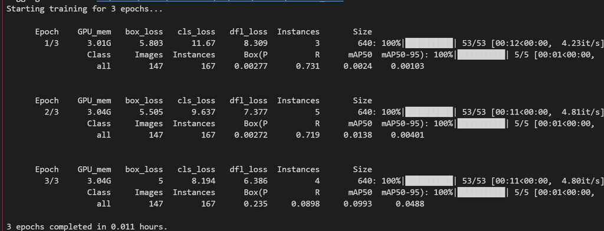

```python
# другие параметры, эпох побольше, кол-во батчей подбирается автоматически
model_yolo10.train(data='data_rec.yaml', epochs = 8, imgsz=640, batch = -1, name = 'variant_two')
```

На 8-ми эпохах результаты стали намного лучше, но можно лучше

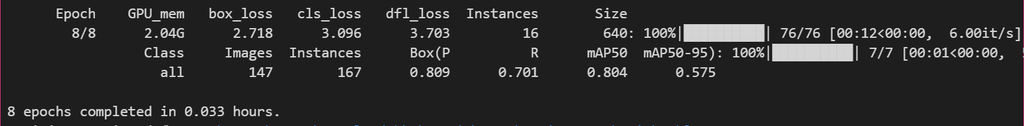

```python
model_yolo10.train(data='data_rec.yaml', epochs = 16, imgsz=640, batch = -1, name = 'variant_three')
```

На 16-ти эпохах результаты ещё лучше, чем на 8-ми, на них я решила остановиться

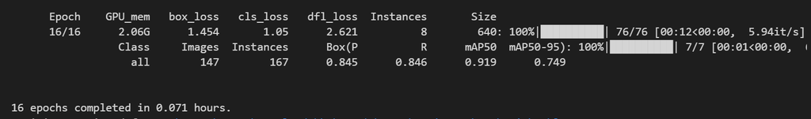

### YOLOv8

Я решила несколько раз обучить v8 с разными значениями у гипперпараметров "epochs" (кол-во эпох) и "batch" (количество батчей).

- Изначально выбраны веса nano, так как они наименьшие (-> обучение будет быстрее)

#### Модель №1

*Гиперпараметры:*

> task=detect, mode=train, model=yolov8n.yaml, data=data_rec.yaml, epochs=12, time=None, patience=100, batch=0.8, imgsz=640, save=True, save_period=-1, cache=False, device=None, workers=8, project=None, name=v_one, exist_ok=False, pretrained=True, optimizer=auto, verbose=True, seed=0, deterministic=True, single_cls=False, rect=False, cos_lr=False, close_mosaic=10, resume=False, amp=True, fraction=1.0, profile=False, freeze=None, multi_scale=False, overlap_mask=True, mask_ratio=4, dropout=0.0, val=True, split=val, save_json=False, save_hybrid=False, conf=None, iou=0.7, max_det=300, half=False, dnn=False, plots=True, source=None, vid_stride=1, stream_buffer=False, visualize=False, augment=False, agnostic_nms=False, classes=None, retina_masks=False, embed=None, show=False, save_frames=False, save_txt=False, save_conf=False, save_crop=False, show_labels=True, show_conf=True, show_boxes=True, line_width=None, format=torchscript, keras=False, optimize=False, int8=False, dynamic=False, simplify=True, opset=None, workspace=None, nms=False, lr0=0.01, lrf=0.01, momentum=0.937, weight_decay=0.0005, warmup_epochs=3.0, warmup_momentum=0.8, warmup_bias_lr=0.1, box=7.5, cls=0.5, dfl=1.5, pose=12.0, kobj=1.0, nbs=64, hsv_h=0.015, hsv_s=0.7, hsv_v=0.4, degrees=0.0, translate=0.1, scale=0.5, shear=0.0, perspective=0.0, flipud=0.0, fliplr=0.5, bgr=0.0, mosaic=1.0, mixup=0.0, copy_paste=0.0, copy_paste_mode=flip, auto_augment=randaugment, erasing=0.4, crop_fraction=1.0, cfg=None, tracker=botsort.yaml

> save_dir=c:\Users\user2\Downloads\hw\runs\detect\v_one - папка, где хранится вся информация об обучении

`batch = 0.8` - для обучения будет использоваться такое количество батчей, при котором на обучение будет тратиться +-80% производительности устройства

```python
# инициализация модели
model_yolo8 = YOLO('yolov8n.yaml')

# обучение модели
model_yolo8.train(data = 'data_rec.yaml', epochs = 12, imgsz = 640, batch = 0.8, name = 'v_one')
```

Количество батчей - 74, нагрузка - 80%

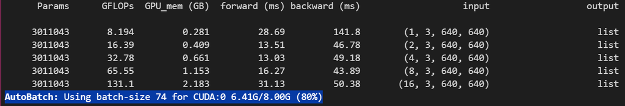

Результат обучения:

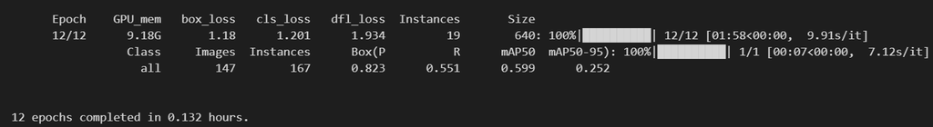

**Модель обучилась не очень хорошо, пробуем другую настройку

#### Модель №2

Веса выбраны small, так как вычислительные ресурсы позволяют взять бОльшие характеристики для модели.

Small идут вторыми после nano в порядке возрастания.

*Гиперпараметры:*

> task=detect, mode=train, model=yolov8s.yaml, data=data_rec.yaml, epochs=16, time=None, patience=100, batch=0.65, imgsz=640, save=True, save_period=-1, cache=False, device=None, workers=8, project=None, name=v_two_s, exist_ok=False, pretrained=True, optimizer=auto, verbose=True, seed=0, deterministic=True, single_cls=False, rect=False, cos_lr=False, close_mosaic=10, resume=False, amp=True, fraction=1.0, profile=False, freeze=None, multi_scale=False, overlap_mask=True, mask_ratio=4, dropout=0.0, val=True, split=val, save_json=False, save_hybrid=False, conf=None, iou=0.7, max_det=300, half=False, dnn=False, plots=True, source=None, vid_stride=1, stream_buffer=False, visualize=False, augment=False, agnostic_nms=False, classes=None, retina_masks=False, embed=None, show=False, save_frames=False, save_txt=False, save_conf=False, save_crop=False, show_labels=True, show_conf=True, show_boxes=True, line_width=None, format=torchscript, keras=False, optimize=False, int8=False, dynamic=False, simplify=True, opset=None, workspace=None, nms=False, lr0=0.01, lrf=0.01, momentum=0.937, weight_decay=0.0005, warmup_epochs=3.0, warmup_momentum=0.8, warmup_bias_lr=0.1, box=7.5, cls=0.5, dfl=1.5, pose=12.0, kobj=1.0, nbs=64, hsv_h=0.015, hsv_s=0.7, hsv_v=0.4, degrees=0.0, translate=0.1, scale=0.5, shear=0.0, perspective=0.0, flipud=0.0, fliplr=0.5, bgr=0.0, mosaic=1.0, mixup=0.0, copy_paste=0.0, copy_paste_mode=flip, auto_augment=randaugment, erasing=0.4, crop_fraction=1.0, cfg=None, tracker=botsort.yaml

> save_dir=c:\Users\user2\Downloads\hw\runs\detect\v_two_s - папка, где хранится вся информация об обучении

`batch = 0.65` - для обучения будет использоваться такое количество батчей, при котором на обучение будет тратиться +-65% производительности устройства

```python
# инициализация модели
model_yolo8s = YOLO('yolov8s.yaml')

# обучение модели
model_yolo8s.train(data = 'data_rec.yaml', epochs = 16, imgsz = 640, batch = 0.65, name = 'v_two_s')
```

33 батча, при обучении нагрузка 68%

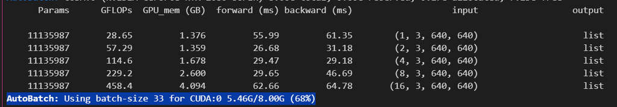

Результат хороший:

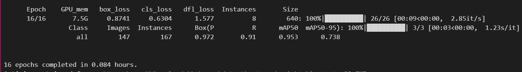

#### Модель №3

- Веса так же взяты small

*Гиперпараметры:*

> epochs=20 - количество эпох поднято до 20-ти, так результаты обучение должны получиться выше, чем у предыдущей настройки модели

> task=detect, mode=train, model=yolov8s.yaml, data=data_rec.yaml, time=None, patience=100, batch=0.7, imgsz=640, save=True, save_period=-1, cache=False, device=None, workers=8, project=None, name=v_3_s, exist_ok=False, pretrained=True, optimizer=auto, verbose=True, seed=0, deterministic=True, single_cls=False, rect=False, cos_lr=False, close_mosaic=10, resume=False, amp=True, fraction=1.0, profile=False, freeze=None, multi_scale=False, overlap_mask=True, mask_ratio=4, dropout=0.0, val=True, split=val, save_json=False, save_hybrid=False, conf=None, iou=0.7, max_det=300, half=False, dnn=False, plots=True, source=None, vid_stride=1, stream_buffer=False, visualize=False, augment=False, agnostic_nms=False, classes=None, retina_masks=False, embed=None, show=False, save_frames=False, save_txt=False, save_conf=False, save_crop=False, show_labels=True, show_conf=True, show_boxes=True, line_width=None, format=torchscript, keras=False, optimize=False, int8=False, dynamic=False, simplify=True, opset=None, workspace=None, nms=False, lr0=0.01, lrf=0.01, momentum=0.937, weight_decay=0.0005, warmup_epochs=3.0, warmup_momentum=0.8, warmup_bias_lr=0.0, box=7.5, cls=0.5, dfl=1.5, pose=12.0, kobj=1.0, nbs=64, hsv_h=0.015, hsv_s=0.7, hsv_v=0.4, degrees=0.0, translate=0.1, scale=0.5, shear=0.0, perspective=0.0, flipud=0.0, fliplr=0.5, bgr=0.0, mosaic=1.0, mixup=0.0, copy_paste=0.0, copy_paste_mode=flip, auto_augment=randaugment, erasing=0.4, crop_fraction=1.0, cfg=None, tracker=botsort.yaml

> save_dir=c:\Users\user2\Downloads\hw\runs\detect\v_3_s - папка, где хранится вся информация об обучении

`batch = 0.7` - для обучения будет использоваться такое количество батчей, при котором на обучение будет тратиться +-70% производительности устройства

```python
model_yolo8s.train(data = 'data_rec.yaml', epochs = 20, imgsz = 640, batch = 0.7, name = 'v_3_s')
```

Кол-во батчей: 32

Нагрузка: 75%

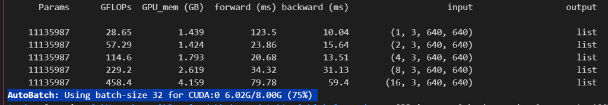

Результаты обучения:

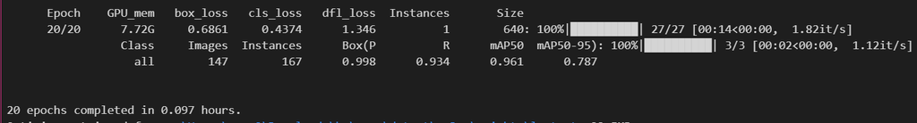

**Модель обучилась очень хорошо

#### Вывод и выбор модели для дальнейшего использования

У модели ****YOLOv8s****, которая была обучена на 20-ти эпохах, самые высокие показатели по всем метрикам, чем у остальных моделей, поэтому я буду использовать её

### Проверка того, как работает модель

```python
#инициализируем модель

model_v8_s20 = YOLO(r'runs\detect\v_3_s\weights\best.pt')
```

```python
test1 = model_v8_s20(r'id_data\valid\Michael_Jackson\Michael_Jackson_0010.jpg')
test1[0].show()
```

```
image 1/1 c:\projects\hw-face-rec-and-id\id_data\valid\Michael_Jackson\Michael_Jackson_0010.jpg: 640x640 1 face, 1810.0ms
Speed: 49.6ms preprocess, 1810.0ms inference, 49.3ms postprocess per image at shape (1, 3, 640, 640)
```

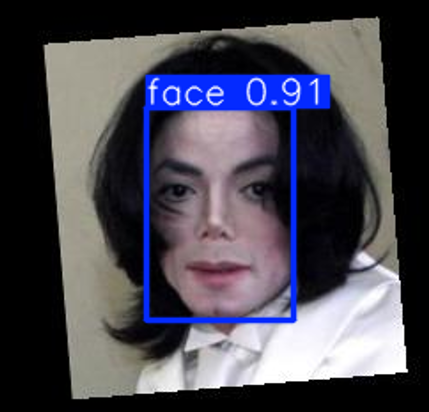

```python
test2 = model_v8_s20(r'id_data\valid\Jennifer_Lopez\Jennifer_Lopez_0004.jpg')
test2[0].show()
```

```
image 1/1 c:\projects\hw-face-rec-and-id\id_data\valid\Jennifer_Lopez\Jennifer_Lopez_0004.jpg: 640x640 1 face, 328.7ms
Speed: 7.0ms preprocess, 328.7ms inference, 4.0ms postprocess per image at shape (1, 3, 640, 640)
```

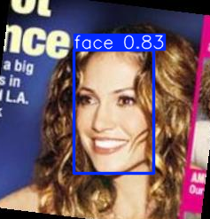

```python
test3 = model_v8_s20(r'id_data\test\Vladimir_Putin\Vladimir_Putin_0041.jpg')
test3[0].show()
```

```
image 1/1 c:\projects\hw-face-rec-and-id\id_data\test\Vladimir_Putin\Vladimir_Putin_0041.jpg: 640x640 1 face, 1067.5ms
Speed: 12.3ms preprocess, 1067.5ms inference, 7.7ms postprocess per image at shape (1, 3, 640, 640)
```

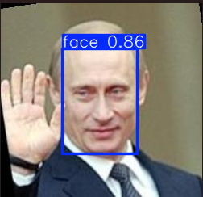

```python
# функция для детекции

def detection_face(model, f_path):
    photo = cv2.imread(f_path)

    # результат детекции
    res = model(photo)
    for r in res:
        print(len(r.boxes))
        for box in r.boxes:
            # получаем координаты результата детекции
            x1, y1, x2, y2 = map(int, box.xyxy[0])

            # выделяем область детекции на фото
            cv2.rectangle(photo, (x1, y1), (x2, y2), (0, 176, 65), 2)
    # вывод фотографии (результата)
    cv2.imshow('Result', photo)
    cv2.waitKey(0)
    cv2.destroyAllWindows()
```

Примеры работы функции:

```python
detection_face(model_v8_s20, r'id_data\test\Wen_Jiabao\Wen_Jiabao_0006.jpg')
```

```
0: 640x640 1 face, 1721.5ms
Speed: 27.3ms preprocess, 1721.5ms inference, 9.2ms postprocess per image at shape (1, 3, 640, 640)
1
```

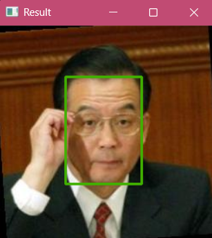

```python
# проверка работы функции
detection_face(model_v8_s20, r'id_data\train\Queen_Elizabeth_II\Queen_Elizabeth_II_0001.jpg')
```

```
0: 640x640 1 face, 751.9ms
Speed: 9.1ms preprocess, 751.9ms inference, 4.0ms postprocess per image at shape (1, 3, 640, 640)
1
```

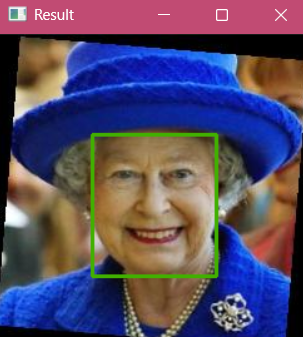

```python
detection_face(model_v8_s20, r'id_data\train\Abdullah_Gul\Abdullah_Gul_0015.jpg')
```

```
0: 640x640 1 face, 569.8ms
Speed: 9.9ms preprocess, 569.8ms inference, 6.4ms postprocess per image at shape (1, 3, 640, 640)
1
```

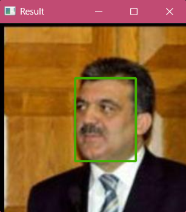

## Алгоритмы для идентификации

```python
from deepface import DeepFace
import os
```

### Создание эмбеддингов для обучения и работа с базой данных

Из всех моделей в DeepFace я решила испозьвать VGG-Face, которая выбрана по умолчанию, так как она использует глубокую свёрточную нейронную сеть, имеет высокую точность и баланс между производительностью и правильностью предсказаний. Эта модель универсальна для решения различных задач, а так же очень хорошо предобучена на самых различных фотографиях с лицами людей, что хорошо сказывается на том, как корректно она будет предсказывать результат на фото с нетипичной постановкой (учитываются эмоции (выражение лица), освещение, ракурсы и тд)

Для распознавания человека модель будет находить эмбеддинги по его лицу и сравнивать их с теми, которые есть в "базе данных" с помощью косинусной схожести (метрика)

- Эмбеддинги будут вычисляться для каждой фотографии из обучающей выборки и храниться в датафрейме.

```python
# функция для вычисления эмбеддингов
def creat_emb(dir):
    results = [] # вся необходимая информация для бд будет добавляться в results
    # находим путь к файлам с фотографиям
    for fold_name in os.listdir(dir):
        fold_name = os.path.join(dir, fold_name)
        if os.path.isdir(fold_name):
            for f_name in os.listdir(fold_name):
                f_path = os.path.join(fold_name, f_name)
                # считываем фото
                img = cv2.imread(f_path)
                res_img = model_v8_s20(img) # детекция
                if len(res_img[0].boxes) != 0:
                    for res in res_img:
                        for box in res.boxes:
                            x1, y1, x2, y2 = map(int, box.xyxy[0])
                            crop = img[y1:y2, x1:x2] # обрезаем фото, оставляя только детектируемую область
                            try:
                                embedding = DeepFace.represent(img_path = crop, model_name='VGG-Face') # вычисляем эмбеддинг
                                # добавляем результат в лист
                                results.append({'folder_name': fold_name,
                                                'file_name': f_name,
                                                'f_path': f_path,
                                                'embedding': embedding})
                            # если эмбеддинг не вычисляется, всё заполняем как None
                            except Exception as e:
                                print(f'ошибка, проблемы с эмбедингом: {e}')
                                results.append({'folder_name': None,
                                                'file_name': None,
                                                'f_path': None,
                                                'embedding': None})
                # если модель детекции ничего не нашла, всё заполняем как None
                else:
                    print('ошибка! проблема с детекцией')
                    results.append({'folder_name': None,
                                     'file_name': None,
                                     'f_path': None,
                                     'embedding': None})
    return results
```

```python
# пути к папке
train_fold = r'id_data\train'

df_train = pd.DataFrame(creat_emb(train_fold)) # вызываем функцию и результат преобразовываем в DataFrame
```

```python
df_train # выводим дф
```

|  | folder_name | file_name | f_path | embedding |
| --- | --- | --- | --- | --- |
| 0 | id_data\train\Abdullah_Gul | Abdullah_Gul_0001.jpg | id_data\train\Abdullah_Gul\Abdullah_Gul_0001.jpg | [{'embedding': [0.0, 0.0, 0.0, 0.0, 0.0, 0.0, ... |
| 1 | id_data\train\Abdullah_Gul | Abdullah_Gul_0005.jpg | id_data\train\Abdullah_Gul\Abdullah_Gul_0005.jpg | [{'embedding': [0.0, 0.0, 0.0, 0.0, 0.0, 0.0, ... |
| 2 | id_data\train\Abdullah_Gul | Abdullah_Gul_0006.jpg | id_data\train\Abdullah_Gul\Abdullah_Gul_0006.jpg | [{'embedding': [0.0, 0.0, 0.0, 0.0, 0.0, 0.0, ... |
| 3 | id_data\train\Abdullah_Gul | Abdullah_Gul_0006.jpg | id_data\train\Abdullah_Gul\Abdullah_Gul_0006.jpg | [{'embedding': [0.0, 0.0, 0.001820393590809222... |
| 4 | id_data\train\Abdullah_Gul | Abdullah_Gul_0007.jpg | id_data\train\Abdullah_Gul\Abdullah_Gul_0007.jpg | [{'embedding': [0.0, 0.0, 0.0, 0.0, 0.0, 0.0, ... |
| ... | ... | ... | ... | ... |
| 3059 | id_data\train\Yoriko_Kawaguchi | Yoriko_Kawaguchi_0014.jpg | id_data\train\Yoriko_Kawaguchi\Yoriko_Kawaguch... | [{'embedding': [0.0, 0.0, 0.0, 0.0, 0.0, 0.0, ... |
| 3060 | id_data\train\Zhu_Rongji | Zhu_Rongji_0002.jpg | id_data\train\Zhu_Rongji\Zhu_Rongji_0002.jpg | [{'embedding': [0.0, 0.0, 0.0, 0.0, 0.0, 0.0, ... |
| 3061 | id_data\train\Zhu_Rongji | Zhu_Rongji_0003.jpg | id_data\train\Zhu_Rongji\Zhu_Rongji_0003.jpg | [{'embedding': [0.0, 0.0, 0.0, 0.0, 0.0, 0.0, ... |
| 3062 | id_data\train\Zhu_Rongji | Zhu_Rongji_0003.jpg | id_data\train\Zhu_Rongji\Zhu_Rongji_0003.jpg | [{'embedding': [0.0, 0.0, 0.0, 0.0, 0.0, 0.0, ... |
| 3063 | id_data\train\Zhu_Rongji | Zhu_Rongji_0007.jpg | id_data\train\Zhu_Rongji\Zhu_Rongji_0007.jpg | [{'embedding': [0.0, 0.0, 0.0, 0.0, 0.0, 0.0, ... |

3064 rows × 4 columns

```python
df_train.to_csv('train.csv') # сохраняем эту версию на всякий случай
```

### Обработка датафрейма

```python
df_train = pd.read_csv('train.csv', sep = ',')
```

```python
df_train.info()
```

```
<class 'pandas.core.frame.DataFrame'>
RangeIndex: 3064 entries, 0 to 3063
Data columns (total 5 columns):
 #   Column       Non-Null Count  Dtype
---  ------       --------------  -----
 0   Unnamed: 0   3064 non-null   int64
 1   folder_name  2743 non-null   object
 2   file_name    2743 non-null   object
 3   f_path       2743 non-null   object
 4   embedding    2743 non-null   object
dtypes: int64(1), object(4)
memory usage: 119.8+ KB
```

В колонках 1-4 321 пропущенное значения -> 321 фотку не удалось считать нормально (либо не вычислился эмбеддинг, либо детекция не обнаружила лицо)

```python
df_train['Unnamed: 0']
```

```
0          0
1          1
2          2
3          3
4          4
        ...
3059    3059
3060    3060
3061    3061
3062    3062
3063    3063
Name: Unnamed: 0, Length: 3064, dtype: int64
```

удаление колонки 'Unnamed: 0', тк в ней просто индексы и она не несёт какого-либо смысла:

```python
df_train = df_train.drop(columns = ['Unnamed: 0'])
```

```python
df_train['folder_name'].value_counts()
```

```
folder_name
id_data\train\Donald_Rumsfeld       56
id_data\train\Hugo_Chavez           55
id_data\train\John_Ashcroft         54
id_data\train\George_W_Bush         54
id_data\train\Ariel_Sharon          52
                                    ..
id_data\train\Ray_Romano             3
id_data\train\Richard_Armitage       3
id_data\train\Thomas_OBrien          3
id_data\train\Sylvester_Stallone     3
id_data\train\Tung_Chee-hwa          3
Name: count, Length: 184, dtype: int64
```

> Length: 184

-> в Датафрейме есть данные о всех 184-ёх человек, фотографии которых были в данных для обучения. Пропуски можно удалить

```python
df_train = df_train.dropna() # удаляем все пропуски
```

```python
df_train.info()
```

```
<class 'pandas.core.frame.DataFrame'>
Index: 2743 entries, 0 to 3063
Data columns (total 4 columns):
 #   Column       Non-Null Count  Dtype
---  ------       --------------  -----
 0   folder_name  2743 non-null   object
 1   file_name    2743 non-null   object
 2   f_path       2743 non-null   object
 3   embedding    2743 non-null   object
dtypes: object(4)
memory usage: 107.1+ KB
```

Создаём колонку, в которой будут храниться имена людей

```python
df_train['Name'] = df_train['folder_name'].str.extract(r'([^\\]+)$')
df_train
```

|  | folder_name | file_name | f_path | embedding | Name |
| --- | --- | --- | --- | --- | --- |
| 0 | id_data\train\Abdullah_Gul | Abdullah_Gul_0001.jpg | id_data\train\Abdullah_Gul\Abdullah_Gul_0001.jpg | [{'embedding': [0.0, 0.0, 0.0, 0.0, 0.0, 0.0, ... | Abdullah_Gul |
| 1 | id_data\train\Abdullah_Gul | Abdullah_Gul_0005.jpg | id_data\train\Abdullah_Gul\Abdullah_Gul_0005.jpg | [{'embedding': [0.0, 0.0, 0.0, 0.0, 0.0, 0.0, ... | Abdullah_Gul |
| 2 | id_data\train\Abdullah_Gul | Abdullah_Gul_0006.jpg | id_data\train\Abdullah_Gul\Abdullah_Gul_0006.jpg | [{'embedding': [0.0, 0.0, 0.0, 0.0, 0.0, 0.0, ... | Abdullah_Gul |
| 3 | id_data\train\Abdullah_Gul | Abdullah_Gul_0006.jpg | id_data\train\Abdullah_Gul\Abdullah_Gul_0006.jpg | [{'embedding': [0.0, 0.0, 0.001820393590809222... | Abdullah_Gul |
| 4 | id_data\train\Abdullah_Gul | Abdullah_Gul_0007.jpg | id_data\train\Abdullah_Gul\Abdullah_Gul_0007.jpg | [{'embedding': [0.0, 0.0, 0.0, 0.0, 0.0, 0.0, ... | Abdullah_Gul |
| ... | ... | ... | ... | ... | ... |
| 3059 | id_data\train\Yoriko_Kawaguchi | Yoriko_Kawaguchi_0014.jpg | id_data\train\Yoriko_Kawaguchi\Yoriko_Kawaguch... | [{'embedding': [0.0, 0.0, 0.0, 0.0, 0.0, 0.0, ... | Yoriko_Kawaguchi |
| 3060 | id_data\train\Zhu_Rongji | Zhu_Rongji_0002.jpg | id_data\train\Zhu_Rongji\Zhu_Rongji_0002.jpg | [{'embedding': [0.0, 0.0, 0.0, 0.0, 0.0, 0.0, ... | Zhu_Rongji |
| 3061 | id_data\train\Zhu_Rongji | Zhu_Rongji_0003.jpg | id_data\train\Zhu_Rongji\Zhu_Rongji_0003.jpg | [{'embedding': [0.0, 0.0, 0.0, 0.0, 0.0, 0.0, ... | Zhu_Rongji |
| 3062 | id_data\train\Zhu_Rongji | Zhu_Rongji_0003.jpg | id_data\train\Zhu_Rongji\Zhu_Rongji_0003.jpg | [{'embedding': [0.0, 0.0, 0.0, 0.0, 0.0, 0.0, ... | Zhu_Rongji |
| 3063 | id_data\train\Zhu_Rongji | Zhu_Rongji_0007.jpg | id_data\train\Zhu_Rongji\Zhu_Rongji_0007.jpg | [{'embedding': [0.0, 0.0, 0.0, 0.0, 0.0, 0.0, ... | Zhu_Rongji |

2743 rows × 5 columns

```python
# импортируем дф на всякий случай
df_train.to_csv('traaaain.csv')
```

```python
traindf = pd.read_csv('traaaain.csv', sep = ',')
```

```python
traindf.info()
```

```
<class 'pandas.core.frame.DataFrame'>
RangeIndex: 2743 entries, 0 to 2742
Data columns (total 6 columns):
 #   Column       Non-Null Count  Dtype
---  ------       --------------  -----
 0   Unnamed: 0   2743 non-null   int64
 1   folder_name  2743 non-null   object
 2   file_name    2743 non-null   object
 3   f_path       2743 non-null   object
 4   embedding    2743 non-null   object
 5   Name         2743 non-null   object
dtypes: int64(1), object(5)
memory usage: 128.7+ KB
```

```python
traindf['embedding']
```

```
0       [{'embedding': [0.0, 0.0, 0.0, 0.0, 0.0, 0.0, ...
1       [{'embedding': [0.0, 0.0, 0.0, 0.0, 0.0, 0.0, ...
2       [{'embedding': [0.0, 0.0, 0.0, 0.0, 0.0, 0.0, ...
3       [{'embedding': [0.0, 0.0, 0.001820393590809222...
4       [{'embedding': [0.0, 0.0, 0.0, 0.0, 0.0, 0.0, ...
                              ...
2738    [{'embedding': [0.0, 0.0, 0.0, 0.0, 0.0, 0.0, ...
2739    [{'embedding': [0.0, 0.0, 0.0, 0.0, 0.0, 0.0, ...
2740    [{'embedding': [0.0, 0.0, 0.0, 0.0, 0.0, 0.0, ...
2741    [{'embedding': [0.0, 0.0, 0.0, 0.0, 0.0, 0.0, ...
2742    [{'embedding': [0.0, 0.0, 0.0, 0.0, 0.0, 0.0, ...
Name: embedding, Length: 2743, dtype: object
```

Дальше мы преобразовываем колонку "embedding", чтобы в дальнейшем можно было с ней работать

**в этой колонке данные храняться как строка (object)

```python
traindf['embedding'] = traindf['embedding'].str.extract(r'\[(.*?)\]') # убираем первые квадратные скобки
traindf
```

|  | Unnamed: 0 | folder_name | file_name | f_path | embedding | Name |
| --- | --- | --- | --- | --- | --- | --- |
| 0 | 0 | id_data\train\Abdullah_Gul | Abdullah_Gul_0001.jpg | id_data\train\Abdullah_Gul\Abdullah_Gul_0001.jpg | {'embedding': [0.0, 0.0, 0.0, 0.0, 0.0, 0.0, 0... | Abdullah_Gul |
| 1 | 1 | id_data\train\Abdullah_Gul | Abdullah_Gul_0005.jpg | id_data\train\Abdullah_Gul\Abdullah_Gul_0005.jpg | {'embedding': [0.0, 0.0, 0.0, 0.0, 0.0, 0.0, 0... | Abdullah_Gul |
| 2 | 2 | id_data\train\Abdullah_Gul | Abdullah_Gul_0006.jpg | id_data\train\Abdullah_Gul\Abdullah_Gul_0006.jpg | {'embedding': [0.0, 0.0, 0.0, 0.0, 0.0, 0.0, 0... | Abdullah_Gul |
| 3 | 3 | id_data\train\Abdullah_Gul | Abdullah_Gul_0006.jpg | id_data\train\Abdullah_Gul\Abdullah_Gul_0006.jpg | {'embedding': [0.0, 0.0, 0.001820393590809222,... | Abdullah_Gul |
| 4 | 4 | id_data\train\Abdullah_Gul | Abdullah_Gul_0007.jpg | id_data\train\Abdullah_Gul\Abdullah_Gul_0007.jpg | {'embedding': [0.0, 0.0, 0.0, 0.0, 0.0, 0.0, 0... | Abdullah_Gul |
| ... | ... | ... | ... | ... | ... | ... |
| 2738 | 3059 | id_data\train\Yoriko_Kawaguchi | Yoriko_Kawaguchi_0014.jpg | id_data\train\Yoriko_Kawaguchi\Yoriko_Kawaguch... | {'embedding': [0.0, 0.0, 0.0, 0.0, 0.0, 0.0, 0... | Yoriko_Kawaguchi |
| 2739 | 3060 | id_data\train\Zhu_Rongji | Zhu_Rongji_0002.jpg | id_data\train\Zhu_Rongji\Zhu_Rongji_0002.jpg | {'embedding': [0.0, 0.0, 0.0, 0.0, 0.0, 0.0, 0... | Zhu_Rongji |
| 2740 | 3061 | id_data\train\Zhu_Rongji | Zhu_Rongji_0003.jpg | id_data\train\Zhu_Rongji\Zhu_Rongji_0003.jpg | {'embedding': [0.0, 0.0, 0.0, 0.0, 0.0, 0.0, 0... | Zhu_Rongji |
| 2741 | 3062 | id_data\train\Zhu_Rongji | Zhu_Rongji_0003.jpg | id_data\train\Zhu_Rongji\Zhu_Rongji_0003.jpg | {'embedding': [0.0, 0.0, 0.0, 0.0, 0.0, 0.0, 0... | Zhu_Rongji |
| 2742 | 3063 | id_data\train\Zhu_Rongji | Zhu_Rongji_0007.jpg | id_data\train\Zhu_Rongji\Zhu_Rongji_0007.jpg | {'embedding': [0.0, 0.0, 0.0, 0.0, 0.0, 0.0, 0... | Zhu_Rongji |

2743 rows × 6 columns

```python
traindf['embedding']
```

```
0       {'embedding': [0.0, 0.0, 0.0, 0.0, 0.0, 0.0, 0...
1       {'embedding': [0.0, 0.0, 0.0, 0.0, 0.0, 0.0, 0...
2       {'embedding': [0.0, 0.0, 0.0, 0.0, 0.0, 0.0, 0...
3       {'embedding': [0.0, 0.0, 0.001820393590809222,...
4       {'embedding': [0.0, 0.0, 0.0, 0.0, 0.0, 0.0, 0...
                              ...
2738    {'embedding': [0.0, 0.0, 0.0, 0.0, 0.0, 0.0, 0...
2739    {'embedding': [0.0, 0.0, 0.0, 0.0, 0.0, 0.0, 0...
2740    {'embedding': [0.0, 0.0, 0.0, 0.0, 0.0, 0.0, 0...
2741    {'embedding': [0.0, 0.0, 0.0, 0.0, 0.0, 0.0, 0...
2742    {'embedding': [0.0, 0.0, 0.0, 0.0, 0.0, 0.0, 0...
Name: embedding, Length: 2743, dtype: object
```

```python
traindf['embedding'] = traindf['embedding'].apply(lambda x: str(x) + ']}') # добавляем в конец каждого элемента ']}', тк эти скобки случайно удалились
traindf
```

|  | Unnamed: 0 | folder_name | file_name | f_path | embedding | Name |
| --- | --- | --- | --- | --- | --- | --- |
| 0 | 0 | id_data\train\Abdullah_Gul | Abdullah_Gul_0001.jpg | id_data\train\Abdullah_Gul\Abdullah_Gul_0001.jpg | {'embedding': [0.0, 0.0, 0.0, 0.0, 0.0, 0.0, 0... | Abdullah_Gul |
| 1 | 1 | id_data\train\Abdullah_Gul | Abdullah_Gul_0005.jpg | id_data\train\Abdullah_Gul\Abdullah_Gul_0005.jpg | {'embedding': [0.0, 0.0, 0.0, 0.0, 0.0, 0.0, 0... | Abdullah_Gul |
| 2 | 2 | id_data\train\Abdullah_Gul | Abdullah_Gul_0006.jpg | id_data\train\Abdullah_Gul\Abdullah_Gul_0006.jpg | {'embedding': [0.0, 0.0, 0.0, 0.0, 0.0, 0.0, 0... | Abdullah_Gul |
| 3 | 3 | id_data\train\Abdullah_Gul | Abdullah_Gul_0006.jpg | id_data\train\Abdullah_Gul\Abdullah_Gul_0006.jpg | {'embedding': [0.0, 0.0, 0.001820393590809222,... | Abdullah_Gul |
| 4 | 4 | id_data\train\Abdullah_Gul | Abdullah_Gul_0007.jpg | id_data\train\Abdullah_Gul\Abdullah_Gul_0007.jpg | {'embedding': [0.0, 0.0, 0.0, 0.0, 0.0, 0.0, 0... | Abdullah_Gul |
| ... | ... | ... | ... | ... | ... | ... |
| 2738 | 3059 | id_data\train\Yoriko_Kawaguchi | Yoriko_Kawaguchi_0014.jpg | id_data\train\Yoriko_Kawaguchi\Yoriko_Kawaguch... | {'embedding': [0.0, 0.0, 0.0, 0.0, 0.0, 0.0, 0... | Yoriko_Kawaguchi |
| 2739 | 3060 | id_data\train\Zhu_Rongji | Zhu_Rongji_0002.jpg | id_data\train\Zhu_Rongji\Zhu_Rongji_0002.jpg | {'embedding': [0.0, 0.0, 0.0, 0.0, 0.0, 0.0, 0... | Zhu_Rongji |
| 2740 | 3061 | id_data\train\Zhu_Rongji | Zhu_Rongji_0003.jpg | id_data\train\Zhu_Rongji\Zhu_Rongji_0003.jpg | {'embedding': [0.0, 0.0, 0.0, 0.0, 0.0, 0.0, 0... | Zhu_Rongji |
| 2741 | 3062 | id_data\train\Zhu_Rongji | Zhu_Rongji_0003.jpg | id_data\train\Zhu_Rongji\Zhu_Rongji_0003.jpg | {'embedding': [0.0, 0.0, 0.0, 0.0, 0.0, 0.0, 0... | Zhu_Rongji |
| 2742 | 3063 | id_data\train\Zhu_Rongji | Zhu_Rongji_0007.jpg | id_data\train\Zhu_Rongji\Zhu_Rongji_0007.jpg | {'embedding': [0.0, 0.0, 0.0, 0.0, 0.0, 0.0, 0... | Zhu_Rongji |

2743 rows × 6 columns

```python
import ast

# преобразование строки в объект Python
traindf['embedding'] = traindf['embedding'].apply(lambda x: ast.literal_eval(x) if isinstance(x, str) else x)
traindf
```

|  | Unnamed: 0 | folder_name | file_name | f_path | embedding | Name |
| --- | --- | --- | --- | --- | --- | --- |
| 0 | 0 | id_data\train\Abdullah_Gul | Abdullah_Gul_0001.jpg | id_data\train\Abdullah_Gul\Abdullah_Gul_0001.jpg | {'embedding': [0.0, 0.0, 0.0, 0.0, 0.0, 0.0, 0... | Abdullah_Gul |
| 1 | 1 | id_data\train\Abdullah_Gul | Abdullah_Gul_0005.jpg | id_data\train\Abdullah_Gul\Abdullah_Gul_0005.jpg | {'embedding': [0.0, 0.0, 0.0, 0.0, 0.0, 0.0, 0... | Abdullah_Gul |
| 2 | 2 | id_data\train\Abdullah_Gul | Abdullah_Gul_0006.jpg | id_data\train\Abdullah_Gul\Abdullah_Gul_0006.jpg | {'embedding': [0.0, 0.0, 0.0, 0.0, 0.0, 0.0, 0... | Abdullah_Gul |
| 3 | 3 | id_data\train\Abdullah_Gul | Abdullah_Gul_0006.jpg | id_data\train\Abdullah_Gul\Abdullah_Gul_0006.jpg | {'embedding': [0.0, 0.0, 0.001820393590809222,... | Abdullah_Gul |
| 4 | 4 | id_data\train\Abdullah_Gul | Abdullah_Gul_0007.jpg | id_data\train\Abdullah_Gul\Abdullah_Gul_0007.jpg | {'embedding': [0.0, 0.0, 0.0, 0.0, 0.0, 0.0, 0... | Abdullah_Gul |
| ... | ... | ... | ... | ... | ... | ... |
| 2738 | 3059 | id_data\train\Yoriko_Kawaguchi | Yoriko_Kawaguchi_0014.jpg | id_data\train\Yoriko_Kawaguchi\Yoriko_Kawaguch... | {'embedding': [0.0, 0.0, 0.0, 0.0, 0.0, 0.0, 0... | Yoriko_Kawaguchi |
| 2739 | 3060 | id_data\train\Zhu_Rongji | Zhu_Rongji_0002.jpg | id_data\train\Zhu_Rongji\Zhu_Rongji_0002.jpg | {'embedding': [0.0, 0.0, 0.0, 0.0, 0.0, 0.0, 0... | Zhu_Rongji |
| 2740 | 3061 | id_data\train\Zhu_Rongji | Zhu_Rongji_0003.jpg | id_data\train\Zhu_Rongji\Zhu_Rongji_0003.jpg | {'embedding': [0.0, 0.0, 0.0, 0.0, 0.0, 0.0, 0... | Zhu_Rongji |
| 2741 | 3062 | id_data\train\Zhu_Rongji | Zhu_Rongji_0003.jpg | id_data\train\Zhu_Rongji\Zhu_Rongji_0003.jpg | {'embedding': [0.0, 0.0, 0.0, 0.0, 0.0, 0.0, 0... | Zhu_Rongji |
| 2742 | 3063 | id_data\train\Zhu_Rongji | Zhu_Rongji_0007.jpg | id_data\train\Zhu_Rongji\Zhu_Rongji_0007.jpg | {'embedding': [0.0, 0.0, 0.0, 0.0, 0.0, 0.0, 0... | Zhu_Rongji |

2743 rows × 6 columns

```python
traindf['embedding']
```

```
0       {'embedding': [0.0, 0.0, 0.0, 0.0, 0.0, 0.0, 0...
1       {'embedding': [0.0, 0.0, 0.0, 0.0, 0.0, 0.0, 0...
2       {'embedding': [0.0, 0.0, 0.0, 0.0, 0.0, 0.0, 0...
3       {'embedding': [0.0, 0.0, 0.001820393590809222,...
4       {'embedding': [0.0, 0.0, 0.0, 0.0, 0.0, 0.0, 0...
                              ...
2738    {'embedding': [0.0, 0.0, 0.0, 0.0, 0.0, 0.0, 0...
2739    {'embedding': [0.0, 0.0, 0.0, 0.0, 0.0, 0.0, 0...
2740    {'embedding': [0.0, 0.0, 0.0, 0.0, 0.0, 0.0, 0...
2741    {'embedding': [0.0, 0.0, 0.0, 0.0, 0.0, 0.0, 0...
2742    {'embedding': [0.0, 0.0, 0.0, 0.0, 0.0, 0.0, 0...
Name: embedding, Length: 2743, dtype: object
```

теперь в 'embedding' находятся словари

```python
# извлечение эмбеддингов из словарей
traindf['embedding'] = traindf['embedding'].apply(lambda x: x['embedding'])
traindf
```

|  | Unnamed: 0 | folder_name | file_name | f_path | embedding | Name |
| --- | --- | --- | --- | --- | --- | --- |
| 0 | 0 | id_data\train\Abdullah_Gul | Abdullah_Gul_0001.jpg | id_data\train\Abdullah_Gul\Abdullah_Gul_0001.jpg | [0.0, 0.0, 0.0, 0.0, 0.0, 0.0, 0.0, 0.0, 0.0, ... | Abdullah_Gul |
| 1 | 1 | id_data\train\Abdullah_Gul | Abdullah_Gul_0005.jpg | id_data\train\Abdullah_Gul\Abdullah_Gul_0005.jpg | [0.0, 0.0, 0.0, 0.0, 0.0, 0.0, 0.0, 0.0, 0.0, ... | Abdullah_Gul |
| 2 | 2 | id_data\train\Abdullah_Gul | Abdullah_Gul_0006.jpg | id_data\train\Abdullah_Gul\Abdullah_Gul_0006.jpg | [0.0, 0.0, 0.0, 0.0, 0.0, 0.0, 0.0, 0.0, 0.0, ... | Abdullah_Gul |
| 3 | 3 | id_data\train\Abdullah_Gul | Abdullah_Gul_0006.jpg | id_data\train\Abdullah_Gul\Abdullah_Gul_0006.jpg | [0.0, 0.0, 0.001820393590809222, 0.0, 0.0, 0.0... | Abdullah_Gul |
| 4 | 4 | id_data\train\Abdullah_Gul | Abdullah_Gul_0007.jpg | id_data\train\Abdullah_Gul\Abdullah_Gul_0007.jpg | [0.0, 0.0, 0.0, 0.0, 0.0, 0.0, 0.0, 0.0, 0.0, ... | Abdullah_Gul |
| ... | ... | ... | ... | ... | ... | ... |
| 2738 | 3059 | id_data\train\Yoriko_Kawaguchi | Yoriko_Kawaguchi_0014.jpg | id_data\train\Yoriko_Kawaguchi\Yoriko_Kawaguch... | [0.0, 0.0, 0.0, 0.0, 0.0, 0.0, 0.0, 0.0, 0.0, ... | Yoriko_Kawaguchi |
| 2739 | 3060 | id_data\train\Zhu_Rongji | Zhu_Rongji_0002.jpg | id_data\train\Zhu_Rongji\Zhu_Rongji_0002.jpg | [0.0, 0.0, 0.0, 0.0, 0.0, 0.0, 0.0, 0.0, 0.0, ... | Zhu_Rongji |
| 2740 | 3061 | id_data\train\Zhu_Rongji | Zhu_Rongji_0003.jpg | id_data\train\Zhu_Rongji\Zhu_Rongji_0003.jpg | [0.0, 0.0, 0.0, 0.0, 0.0, 0.0, 0.0, 0.0, 0.0, ... | Zhu_Rongji |
| 2741 | 3062 | id_data\train\Zhu_Rongji | Zhu_Rongji_0003.jpg | id_data\train\Zhu_Rongji\Zhu_Rongji_0003.jpg | [0.0, 0.0, 0.0, 0.0, 0.0, 0.0, 0.0, 0.04735205... | Zhu_Rongji |
| 2742 | 3063 | id_data\train\Zhu_Rongji | Zhu_Rongji_0007.jpg | id_data\train\Zhu_Rongji\Zhu_Rongji_0007.jpg | [0.0, 0.0, 0.0, 0.0, 0.0, 0.0, 0.0, 0.0, 0.0, ... | Zhu_Rongji |

2743 rows × 6 columns

```python
traindf['embedding']
```

```
0       [0.0, 0.0, 0.0, 0.0, 0.0, 0.0, 0.0, 0.0, 0.0, ...
1       [0.0, 0.0, 0.0, 0.0, 0.0, 0.0, 0.0, 0.0, 0.0, ...
2       [0.0, 0.0, 0.0, 0.0, 0.0, 0.0, 0.0, 0.0, 0.0, ...
3       [0.0, 0.0, 0.001820393590809222, 0.0, 0.0, 0.0...
4       [0.0, 0.0, 0.0, 0.0, 0.0, 0.0, 0.0, 0.0, 0.0, ...
                              ...
2738    [0.0, 0.0, 0.0, 0.0, 0.0, 0.0, 0.0, 0.0, 0.0, ...
2739    [0.0, 0.0, 0.0, 0.0, 0.0, 0.0, 0.0, 0.0, 0.0, ...
2740    [0.0, 0.0, 0.0, 0.0, 0.0, 0.0, 0.0, 0.0, 0.0, ...
2741    [0.0, 0.0, 0.0, 0.0, 0.0, 0.0, 0.0, 0.04735205...
2742    [0.0, 0.0, 0.0, 0.0, 0.0, 0.0, 0.0, 0.0, 0.0, ...
Name: embedding, Length: 2743, dtype: object
```

Остались только эмбеддинги. Сохраняем эту версию датафрейма как окончательную

```python
traindf.to_csv('emb_db.csv')
```

### API распознавание лица

```python
from sklearn.metrics.pairwise import cosine_similarity # метрика для сравнения эмбеддингов
import matplotlib.pyplot as plt
```

Для возможности применения нейронной сети в различных информационных системах можно создать функцию, которая будет принимать такие параметры как: путь к изображению, модель и данные (датафрейм). Возвращать она будет возвращать результат отработки обеих моделей (детекции и распознавания), а так же выводить обрезанное фото с лицом (то есть ту часть фотографии, по которой вычисляется эмбеддинг)

```python
def identity_face(img, model, df):
    '''
    Параметры функции:
    img - путь к файлу с фотографией
    model - модель детекции (YOLO)
    df - база данных в формате pandas Dataframe
    '''
    res = []
    photo = cv2.imread(img) # чтение файла с фото
    res_detect = model.predict(photo) # детекция
    if len(res_detect[0].boxes) == 1: # проверка, что найдено только одно лицо (не больше, не меньше)
        x1, y1, x2, y2 = map(int, res_detect[0].boxes.xyxy[0])
        crop_ph = photo[y1:y2, x1:x2] # обрезка фотографии
        # отображение обрезанной части картинки
        plt.figure(figsize=(5, 5))
        plt.imshow(crop_ph)
        plt.title('Cropped Image')
        plt.axis('off')
        plt.show()
        try:
            # вычисление эмбеддинга
            embedding_input = DeepFace.represent(img_path = crop_ph, model_name='VGG-Face')[0]['embedding']
            max_prob = 0.4 # переменная для записи наилучшего совпадения, минимальное совпадение 40%
            best_res = None # переменная для записи всей строки из датафрейма, в которой хранится наилучшее совпадение
            for i, embedding_db in enumerate(df['embedding']): # проходимся по колонке с эмбеддингами
                similarity = cosine_similarity([embedding_input], [embedding_db])[0][0] # вычисление косинусной схожести
                if similarity > max_prob:
                    max_prob = similarity
                    best_res = df.iloc[i]
            # если переменная best_res не пустая, выводим результат
            if best_res is not None:
                res = {'Name': best_res['Name'], 'similarity': max_prob}
                print(f'Имя: {res["Name"]}\nСовпадение: {res["similarity"]}')
                # добавляю вывод фотографии из бд
                res_photo_p = best_res['f_path']
                res_answ = cv2.cvtColor(cv2.imread(res_photo_p), cv2.COLOR_BGR2RGB)
                plt.figure(figsize=(5, 5))
                plt.imshow(res_answ)
                plt.title('Cropped Image')
                plt.axis('off')
                plt.show()
                return res
            else:
                print('Совпадения не найдены')
                return None
        except:
            print('Лицо не обнаружено')
            return None
    else:
        print('Ошибка, обнаружено много лиц. Пожалйста, выберите фото с одним лицом.')
        return None
```

Примеры того, как работает функция:

```
0: 640x640 1 face, 231.0ms
Speed: 10.0ms preprocess, 231.0ms inference, 1.0ms postprocess per image at shape (1, 3, 640, 640)
```

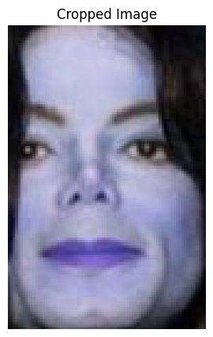

```
Имя: Michael_Jackson
Совпадение: 0.7210624840831067
```

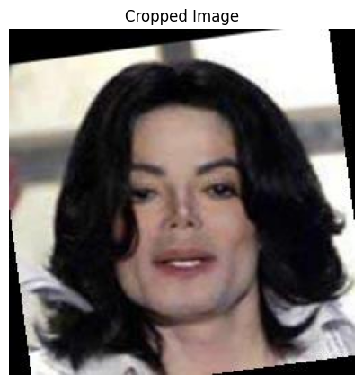

```
{'Name': 'Michael_Jackson', 'similarity': np.float64(0.7210624840831067)}
```

```python
identity_face(r'id_data\valid\Michael_Jackson\Michael_Jackson_0001.jpg', model_v8_s20, traindf)
```

```
0: 640x640 1 face, 247.9ms
Speed: 7.0ms preprocess, 247.9ms inference, 2.0ms postprocess per image at shape (1, 3, 640, 640)
```

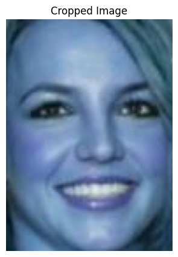

```
Имя: Britney_Spears
Совпадение: 0.6479501805253701
```

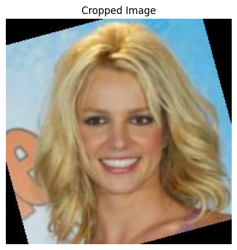

```
{'Name': 'Britney_Spears', 'similarity': np.float64(0.6479501805253701)}
```

```python
identity_face(r'id_data\test\Britney_Spears\Britney_Spears_0014.jpg', model_v8_s20, traindf)
```

```
0: 640x640 1 face, 214.9ms
Speed: 7.9ms preprocess, 214.9ms inference, 1.0ms postprocess per image at shape (1, 3, 640, 640)
```

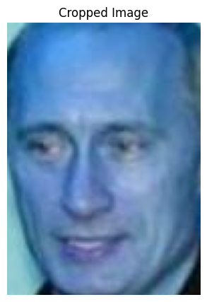

```
Имя: Vladimir_Putin
Совпадение: 0.699861290959066
```

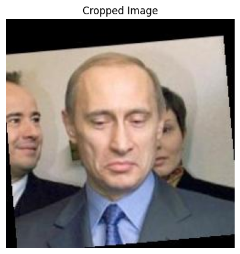

```
{'Name': 'Vladimir_Putin', 'similarity': np.float64(0.699861290959066)}
```

```python
identity_face(r'id_data\test\Vladimir_Putin\Vladimir_Putin_0003.jpg', model_v8_s20, traindf)
```

## Графическое приложение для демонстрации работы нейронной сети и разработанного API

Графическое приложение реализовано с помощью библиотеки Streamlit. Код самого приложения находится в файле "st.py"

Пример работы графического приложения:

[video not shown]

Пример работы графического приложения в случае, когда не удалось распознать лицо:

[video not shown]

Пример работы графического приложения в случае, когда удалось распознать лицо, но не удалось его идентифицировать:

[video not shown]

## Unit-тесты

- Функции для unit-тестов прописаны в файле `functionals.py`
- Сами unit-тесты находятся в скрипте `unit_tests.py`

Результат запуска unit-тестов:

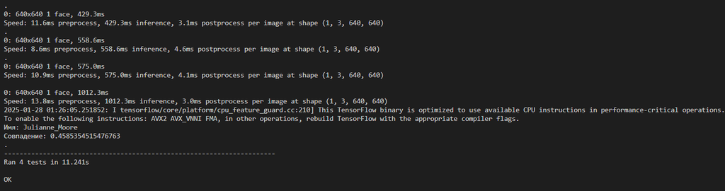

> Из 4-ёх тестов все сработали положительно

## Отчёт

- Обучено несколько моделей для задачи детекции, из них была выбрана лучшая
- Сделано API (функция) для распознавание лица по фото
- Реализовано графическое приложение для распознавание лица по фото
- Сделаны Unit-тесты